# Florida Palmetto (*Sabal etonia* and *Serenoa repens*): 1981-2017

Genevieve Chiong

1/31/2021

```r
# Read in the data
palmetto <- read_csv(here("data", "palmetto.csv"))

# Add species names and select for variables of interest
palmetto_clean <- palmetto %>%
  mutate(species_name = case_when(species == 1 ~ "Serenoa repens",
                                  species == 2 ~ "Sabal etonia")) %>%
  select(species_name, height:green_lvs)

# Change species_name column to a factor
palmetto_clean$species_name <- as.factor(palmetto_clean$species_name)
```

#### **Data visualizations exploring differences in plant height, canopy length, canopy width, and number of green leaves for two Florida palmetto species, *Sabal etonia* and *Serenoa repens***

```r
# Take a look at the data
#palmetto_clean %>%
  #ggpairs(aes(color = species_name))

# Check the levels (Sabal etonia is 0, Serenoa repens is 1)
#levels(palmetto_clean$species_name)
```

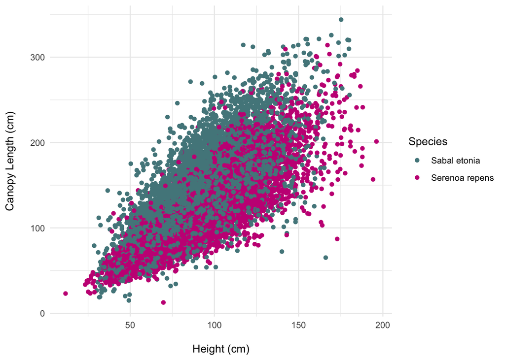

**Figure 1.** Comparison of plant height (cm) and canopy length (cm) between two Florida palmetto species, *Sabal etonia* (teal) and *Serenoa repens* (magenta), using data from 1981-2017. Data: Abrahamson, W.G. 2019.

```r
# Look at trends across variables for the two palmetto species

# Graph of height vs. canopy length

ggplot(data = palmetto_clean,
       aes(x = height,
           y = length)) +
  geom_jitter(aes(color = species_name)) +
                scale_color_manual(values=c("cadetblue4", "mediumvioletred")) +
                labs(x = "\nHeight (cm)",
                     y = "Canopy Length (cm)\n",
                     color = "Species") +
                theme_minimal()
```

*Sabal etonia* and *Serenoa erpens* have overall similar plant height (cm) and canopy length (cm). However, *Sabal etonia* has a slightly larger canopy length and *Serenoa repens* has a slightly greater height.

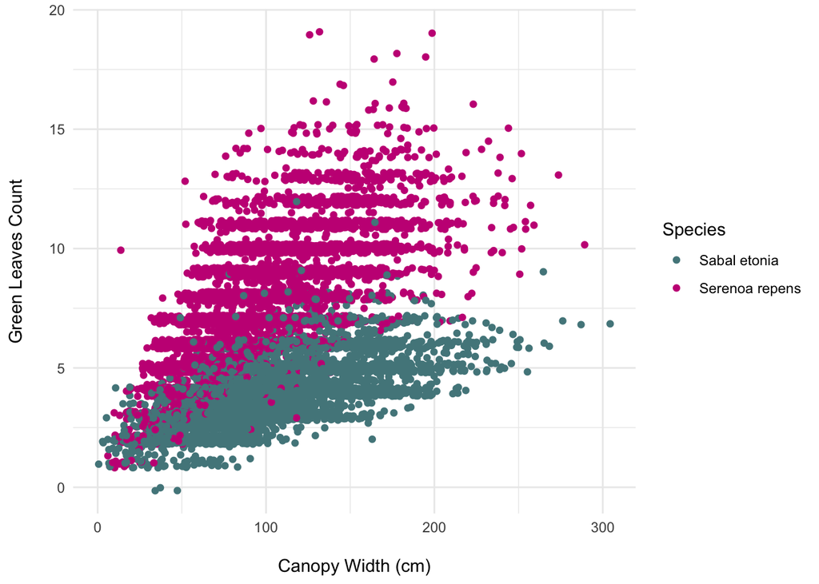

**Figure 2.** Comparison of canopy width (cm) and number of green leaves between two Florida palmetto species, *Sabal etonia* (teal) and *Serenoa repens* (magenta), using data from 1981-2017. Data: Abrahamson, W.G. 2019.

```r
# Graph of canopy width vs number of green leaves

   ggplot(data = palmetto_clean,
       aes(x = width,
           y = green_lvs)) +
 geom_jitter(aes(color = species_name)) +
  scale_color_manual(values=c("cadetblue4", "mediumvioletred")) +
  labs(x = "\nCanopy Width (cm)",
       y = "Green Leaves Count\n",
       color = "Species") +
  theme_minimal()
```

*Sabal etonia* has a slightly larger canopy width (cm) than *Serenoa repens*, whereas *Serenoa repens* has considerably more green leaves.

#### **Binary Logistic Regression**

```r
# Binary logistic regression using plant height, canopy length, canopy width, and number of green leaves as predictor values to understand how they relate to the probability of a plant being Serenoa repens or Sabal etonia

# Sabal etonia is first '0' factor level, Serenoa repens is '1'

palmetto_blr <- glm(species_name ~ height + length + width + green_lvs,
                    data = palmetto_clean,
                    family = "binomial")

# Look at the model
#palmetto_blr

#summary(palmetto_blr)

# Get a tidy version w/broom
palmetto_blr_tidy <- broom::tidy(palmetto_blr)

# Coefficients are for the predictor variables that relate to the log odds of the "Serenoa repens" outcome (level = 1)

#summary(palmetto_blr_tidy)
```

**Table 1.** The binary logistic regression model results using plant height, canopy length, canopy width, and number of green leaves as predictor variables that relate to the probability of a plant being *Serenoa repens*. Data: Abrahamson, W.G. 2019.

```r
# Create a table containing the binary logistic regression model results

palmetto_blr_tidy$p.value[palmetto_blr_tidy$p.value < 0.0001] <- "<0.0001"

kable(palmetto_blr_tidy,
      col.names = c("Term",
                    "Estimate",
                    "Standard Error",
                    "Statistic",
                    "P-value")) %>%
  kable_styling(bootstrap_options = "striped",
                full_width = FALSE)
```

| Term | Estimate | Standard Error | Statistic | P-value |
| --- | --- | --- | --- | --- |
| (Intercept) | -3.2266851 | 0.1420708 | -22.71180 | <0.0001 |
| height | 0.0292173 | 0.0023061 | 12.66984 | <0.0001 |
| length | -0.0458233 | 0.0018661 | -24.55600 | <0.0001 |
| width | -0.0394434 | 0.0021000 | -18.78227 | <0.0001 |
| green_lvs | 1.9084747 | 0.0388634 | 49.10728 | <0.0001 |

#### **Classification success rate of binary logistic regression model**

**Table 2.** The number of *Serenoa repens* and *Sabal etonia* palmetto plants correctly and incorrectly classified using the binary logistic regression model with four predictor variables: plant height, canopy length, canopy width, and number of green leaves. Data: Abrahamson, W.G. 2019.

```r
# Evaluate how successfully the binary logistic regression model would "classify" a plant as the correct species, using a 50% cutoff

blr_fitted <- palmetto_blr %>%
  broom::augment(type.predict = "response")

blr_fitted_success <- blr_fitted %>%
  mutate(predicted_species = case_when(.fitted >= 0.5 ~ "Serenoa repens",
                                       .fitted < 0.5 ~ "Sabal etonia"))

blr_fitted_success$correct_classification <- ifelse(blr_fitted_success$species_name == blr_fitted_success$predicted_species, "Correct", "Incorrect")

# Create a table that shows the count of plants correctly classified and incorrectly classified
palmetto_counts <- blr_fitted_success %>%
  tabyl(species_name, correct_classification)

# Add column for % correctly classified
palmetto_counts_edited <- palmetto_counts %>%
  mutate(percent_correct = round((palmetto_counts$Correct/(palmetto_counts$Correct + palmetto_counts$Incorrect)*100), 2))

# Create a finalized table for count of plants correctly and incorrectly classified as well as % correctly classified
kable(palmetto_counts_edited,
      col.names = c("Species",
                    "Correctly Classified",
                    "Incorrectly Classified",
                    "% Correctly Classified")) %>%
  kable_styling(bootstrap_options = "striped",
                full_width = FALSE)
```

| Species | Correctly Classified | Incorrectly Classified | % Correctly Classified |
| --- | --- | --- | --- |
| Sabal etonia | 5701 | 454 | 92.62 |
| Serenoa repens | 5548 | 564 | 90.77 |

#### **Citations**

Abrahamson, W.G. 2019. Survival, growth and biomass estimates of two dominant palmetto species of south-central Florida from 1981 - 2017, ongoing at 5-year intervals ver 1. Environmental Data Initiative. https://doi.org/10.6073/pasta/f2f96ec76fbbd4b9db431c79a770c4d5